# Practical Machine Learning Course Project

Abhinav Agarwal

6 December 2018

# Synopsis

For this project, we are given data from accelerometers on the belt, forearm, arm, and dumbell of 6 research study participants. Our training data consists of accelerometer data and a label identifying the quality of the activity the participant was doing. Our testing data consists of accelerometer data without the identifying label. Our goal is to predict the labels for the test set observations.

More information is available from the website here: http://groupware.les.inf.puc-rio.br/har (Weight Lifting Exercise Dataset).

# Data Preparation

To load the datasets we execute:

```r
suppressMessages(library(caret))

training <- read.csv('pml-training.csv', sep = ",")
testing <-read.csv('pml-testing.csv', sep = ",")
```

## Partioning the training set into two

Partioning Training data set into two data sets, 60% for Training, 40% for Testing:

```r
inTrain <- createDataPartition(y=training$classe, p=0.6, list=FALSE)
myTraining <- training[inTrain, ]; myTesting <- training[-inTrain, ]
dim(myTraining); dim(myTesting)
```

```
## [1] 11776   160
```

```
## [1] 7846  160
```

## Cleaning the data

Reducing the number of features by removing variables with nearly zero variance, variables that are almost always NA, and variables that don’t make intuitive sense for prediction. We decide which ones to remove by analyzing myTraining, and perform the identical removals on myTesting:

```r
# remove variables with nearly zero variance
nzv <- nearZeroVar(myTraining)
myTraining <- myTraining[, -nzv]
myTesting <- myTesting[, -nzv]

# remove variables that are almost always NA
mostlyNA <- sapply(myTraining, function(x) mean(is.na(x))) > 0.95
myTraining <- myTraining[, mostlyNA==F]
myTesting <- myTesting[, mostlyNA==F]

# remove variables that don't make intuitive sense for prediction (X, user_name, raw_timestamp_part_1, raw_timestamp_part_2, cvtd_timestamp), which happen to be the first five variables
myTraining <- myTraining[, -(1:5)]
myTesting <- myTesting[, -(1:5)]
```

# Implementing Machine Learning Algorithms

## Decision Tree

Here, we make a decision tree and plot it using fancy plot library.

```r
library(rpart)
library(rattle)
```

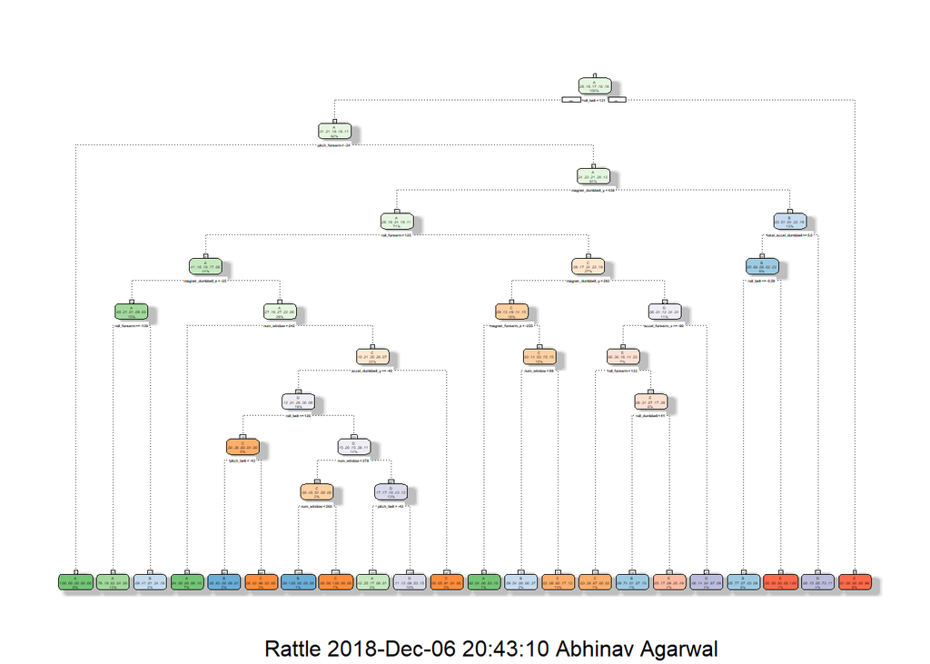

```r
modFitA1 <- rpart(classe ~ ., data=myTraining, method="class")
fancyRpartPlot(modFitA1)
```

## Random Forests

We use Random Forests because it can deal with lots of highly correlated features. We also creat a trainControl object to specify 10-Fold Cross Validation one time and pass it to the train function. Then our code to create the model is:

```r
cvCtrl <- trainControl('cv', 10, savePred=T)
set.seed(111)
 model <- train(classe ~ ., data = myTraining, method = 'rf', trControl = cvCtrl)
model
```

```
## Random Forest
##
## 11776 samples
##    53 predictor
##     5 classes: 'A', 'B', 'C', 'D', 'E'
##
## No pre-processing
## Resampling: Cross-Validated (10 fold)
## Summary of sample sizes: 10597, 10599, 10598, 10598, 10599, 10600, ...
## Resampling results across tuning parameters:
##
##   mtry  Accuracy   Kappa
##    2    0.9928678  0.9909773
##   27    0.9957552  0.9946303
##   53    0.9926987  0.9907644
##
## Accuracy was used to select the optimal model using the largest value.
## The final value used for the model was mtry = 27.
```

# Making Test Set Predictions

```r
# predict on test set
preds <- predict(model, newdata=testing)

# convert predictions to character vector
preds <- as.character(preds)

# create function to write predictions to files
pml_write_files <- function(x) {
    n <- length(x)
    for(i in 1:n) {
        filename <- paste0("problem_id_", i, ".txt")
        write.table(x[i], file=filename, quote=F, row.names=F, col.names=F)
    }
}

# create prediction files to submit
pml_write_files(preds)
```

# References

The following references were used in this report:

[Practical Machine Learning Course Project by Ricardo Silva Carvalho](http://ricardoscr.github.io/practicalmachinelearning/)

[Final Project Report - Practical Machine Learning Course by Unknown](https://rstudio-pubs-static.s3.amazonaws.com/29426_041c5ccb9a6a4bedb204e33144bb0ad4.html)

[Practical Machine Learning - Course Project by justmarkham](http://justmarkham.github.io/PracticalMachineLearning/)